# Reprodata_assignment1

JHR3200

Thursday, October 15, 2015

## Introduction

[This markdown file contains the work submitted for the coursera reproducibe research course assignment 1 details can be found here.](https://class.coursera.org/repdata-033/human_grading/view/courses/975146/assessments/3)

To summarise the assignment is to take data from a personal activity device. This device collects data at 5 minute intervals through out the day. The data consists of two months of data from an anonymous individual collected during the months of October and November, 2012 and include the number of steps taken in 5 minute intervals each day. The student has to perform some simple analysis on this data and submit that analysis using Rmarkdown in a manner consistent with **Literate/Statistical Programming**

#### The dataset

The variables included in this dataset are: -steps: Number of steps in a 5-minute interval –(missing values are coded as NA) -date: The date on which the measurement was taken in YYYY-MM-DD format -interval: Identifier for the 5-minute interval in which measurement was taken

[The data was downloaded from here](https://d396qusza40orc.cloudfront.net/repdata%2Fdata%2Factivity.zip)

```r
dataset<-read.csv('activity.csv')
```

#### Question 1. What is mean total number of steps taken per day?

Note: **ignore the missing values in the dataset.**

```r
#calculate the total steps per day NA's ar eignored using na.omit
dailystepsum <- aggregate(steps~date, dataset,sum,na.action=na.omit)
```

Next the mean and median steps across all days are calculated

```r
#calculate the mean ignoring NA's
mestep<-signif(mean(dailystepsum$step), digits = 8)
#calculate the median ignoring NA's
mistep<-signif(median(dailystepsum$step), digits = 8)
```

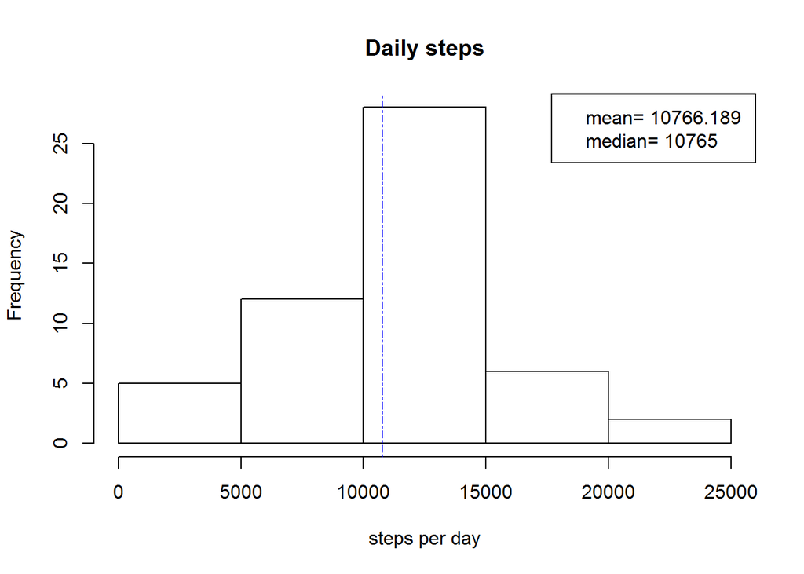

```r
#Plot a histogram of the daily data
hist(dailystepsum$steps,main = "Daily steps",xlab = "steps per day")

#present the mean and median in the legend box
legtext<-c(paste("mean=",as.character(mestep),""),
           paste("median=",as.character(mistep),""))
legend("topright",legtext)
abline(v =mestep, col="RED", lty = 3)
abline(v =mistep, col="BLUE", lty = 6)
```

#### Question 2 What is the average daily activity pattern?

#### 2.1 Make a time series plot 5-minute interval and the average number of steps taken across all days

The **aggerate()** function is used to calculate the mean number of steps per interval across all days and stored in the data frame **meandailydat{}** .This data is plotted using plot to show mean activity dataset.

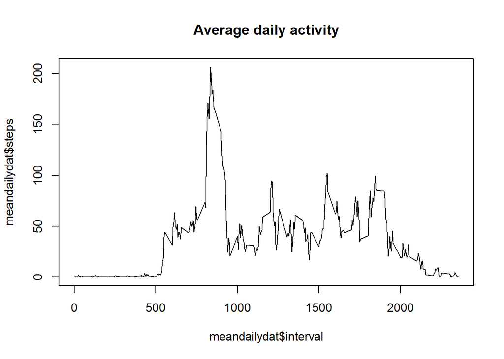

```r
#Generate the mean step dataframe across all days
meandailydat <- aggregate(steps~interval, dataset,mean)

# Plot this dataset
plot(meandailydat$interval,meandailydat$steps,type="l",main="Average daily activity")
```

```r
#find the index of the maximum value`
maxindx<-which.max(meandailydat$step)
maxstep<-meandailydat$step[maxindx]
#use this index to pring the interval in which it occurs
fiveminmax<-meandailydat$interval[maxindx]
```

#### 3.1 Devise an imputation strategy to substitute all missing values in the raw dataset

#### 3.2 how does the imputation effect the mean and median values calculated for the orignal datsset in question 1

The **is.na()** function is used to calculate the number of NA in the raw **dataset{}**

```r
#use is.na() --> number of NA in the raw dataset
numnas<-sum(is.na(dataset$steps))
```

##### The following Imputation stragety was used

The **meandailydata{}** dataframe(mean number of steps per interval across 2 months) generated in question 2 above, contains the mean dataset over all days, As such its interval values are a good proxy for missing values. The strategy is to replace any missing values (NA’s) in raw **dataset{}** with the appropriate **meandailydata{}** value.The results are stored in the new dataframe **imputeddataset{}**.

```r
#if a NA's is present at a given interval find the corresponding value from
#the meandailydat{} dataframe and substituded in its place

    for(i in 1:nrow(dataset)) {
        if (is.na(dataset[i,1])) {
          imputeinterval<-dataset[i,3]#if NA tag interval
          #find corresponding index for daily average data frame
          imputeindex<-match(imputeinterval,meandailydat$interval)
          #replace NA with corresponding average for thatinterval
          dataset[i,1]<-imputevalue<-meandailydat$steps[imputeindex]
        }
    }

#Create a new dataset that is equal to the original dataset
#but with the missing data filled in.
imputeddataset<-dataset
```

To examine the effect of the imputation the analysis in question 1 is repeated on the imputed dataset **imputeddataset{}**

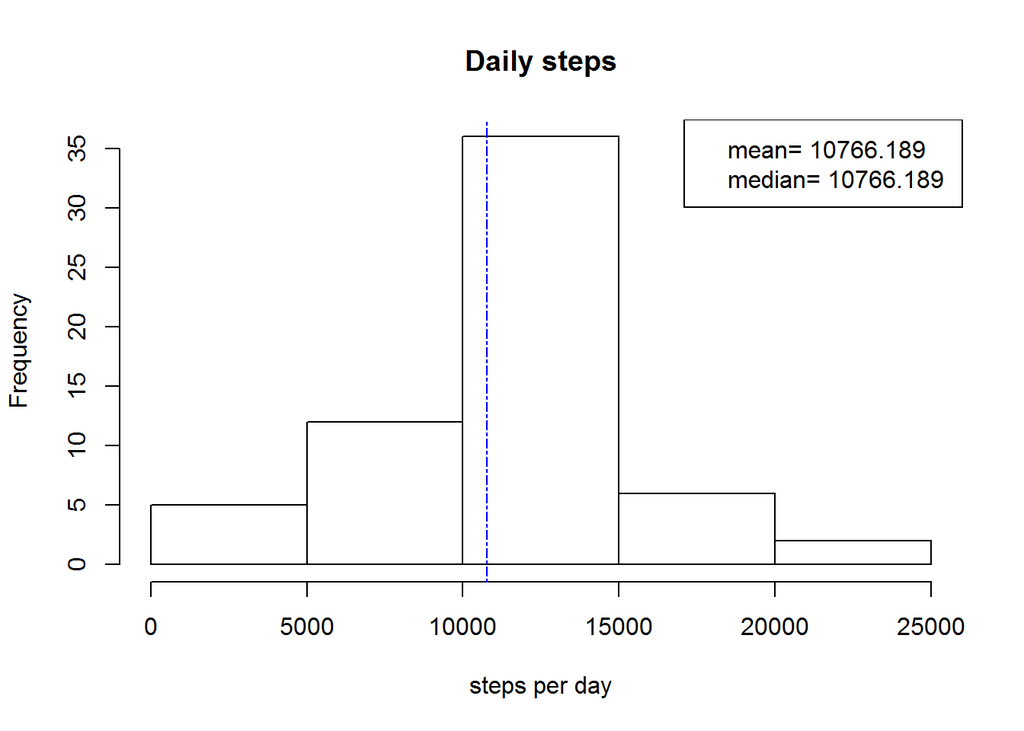

```r
#Recalculate the total steps per day with imputed dataset
dailystepsum <- aggregate(steps~date, imputeddataset,sum)

#calculate the mean ignoring NA's
mestep<-signif(mean(dailystepsum$step), digits = 8)
#calculate the median ignoring NA's
mistep<-signif(median(dailystepsum$step), digits = 8)

#Plot a histogram of the daily data
     hist(dailystepsum$steps,main = "Daily steps",xlab = "steps per day")

     #present the mean and median in the legend box
     legtext<-c(paste("mean=",as.character(mestep),""),
                paste("median=",as.character(mistep),""))
     legend("topright",legtext)
     abline(v =mestep, col="RED", lty = 3)
     abline(v =mistep, col="BLUE", lty = 6)
```

```r
#dev.off()
```

#### Question 4 Examine the diffrence between the activity on weekends and week days using # the imputed dataset

To do this the **asWdays()** function was used to create a new data set **withweekdays{}** which has an additional factor “day” tagging the day name to the date, then by subsetting on this factor two new data sets **weekday{}** and **weekend{}** are generated using the **arrange()** function from the dplyr package.

```r
#load dplyr but do not display output
library(dplyr)
#Calculate the corresponding days for the measurement dates
dates<-factor(dataset[,2])
asWdays<-weekdays(as.Date(dates))

#Create a new dataframe with  weekdays included
withweekdays<-data.frame(dates=dates, day=asWdays,
                         steps=dataset[,1], interval=dataset[,3] )

#Sort by day and create two dataframes 1 for weekdays and one for the weekend
mon<- subset(withweekdays, day == "Monday")
tue<- subset(withweekdays, day == "Tuesday")
wed<- subset(withweekdays, day == "Wednesday")
thu<- subset(withweekdays, day == "Thursday")
fri<- subset(withweekdays, day == "Friday")
sat<- subset(withweekdays, day == "Saturday")
sun<- subset(withweekdays, day == "Sunday")
weekday<-rbind(mon,tue,wed,thu,fri)
weekend<-rbind(sat,sun)


#Rearrange by date using dplyr function arrange()
weekday<-arrange(weekday, dates)
weekend<-arrange(weekend, dates)

# calculate the typical mean weekday and weekend day
meanweekday <- aggregate(steps~interval, weekday,mean)
meanweekend <- aggregate(steps~interval, weekend,mean)
```

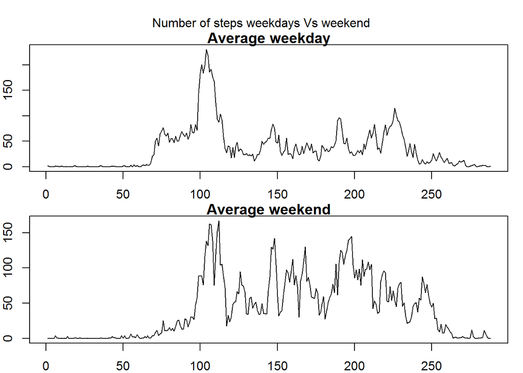

```r
#Build a plot comparing the weekend and weekday dataframes
par(mfrow = c(2, 1), mar = c(2, 2, 1, 1), oma = c(0, 0, 2, 0))
  plot(meanweekday$steps,meanweekday$Interval, main = "Average weekday",type="l")
  plot(meanweekend$steps,meanweekend$Interval, main = "Average weekend",type="l")
  mtext("Number of steps weekdays Vs weekend", outer = TRUE)
```